# 05_Segmentation d’images cérébrales

Ali FRADY

22/01/2021

On se propose dans cette section de segmenter les tissus cérébraux en utilisant une méthode de classification non supervisée (kmeans, GMM, …).

1. Appliquez à l’image « irm1_cut.jpg » une méthode de classification non supervisée pour la segmenter en quatre régions. A chaque pixel de l’image sera attribuée une nouvelle étiquette selon la région à laquelle il appartient. L’image d’étiquettes finale sera sauvegardée sous le nom « segmentation_methode.jpg ». Où « methode » désigne le nom de la méthode que vous avez utilisée. Par exemple le résultat de la segmentation avec kmeans sera appelé « segmentation_kmeans.jpg ».

```python
import numpy as np
import cv2
from matplotlib import pyplot as plt
RMI     = cv2.imread('data/irm1_cut.jpg', 0)
```

```r
library(tidyverse)
k_means = l = kmeans(as.vector(t(py$RMI)), 4, iter.max = 1000)
RMI_Kmeans_segmented = data.frame(
  x = rep(1:dim(py$RMI)[1], each = dim(py$RMI)[2]),
  y = rep(1:dim(py$RMI)[2], dim(py$RMI)[1]),
  Inensity  = as.vector(t(py$RMI)),
  cluster = k_means$cluster
) %>%
  mutate(
    clus1 = ifelse(cluster == 1, 51, 0),
    clus2 = ifelse(cluster == 2, 81, 0),
    clus3 = ifelse(cluster == 3, 161, 0),
    clus4 = ifelse(cluster == 4, 255, 0)
  )

kmeans_segments =  matrix(RMI_Kmeans_segmented$cluster, nrow = 625)

clus1 = matrix(RMI_Kmeans_segmented$clus1, nrow = 625)
clus2 = matrix(RMI_Kmeans_segmented$clus2, nrow = 625)
clus3 = matrix(RMI_Kmeans_segmented$clus3, nrow = 625)
clus4 = matrix(RMI_Kmeans_segmented$clus4, nrow = 625)
load("10fev.RData")
```

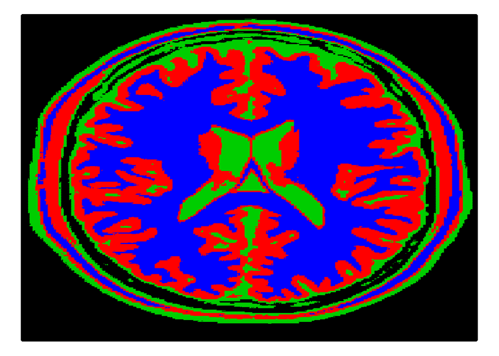

```r
library(ggplot2)
allLevels <- ggplot(data = RMI_Kmeans_segmented, aes(x = y, y = -x)) +
  geom_point(colour = factor(RMI_Kmeans_segmented$cluster))+
      theme_void() + theme(legend.position="none")

allLevels
```

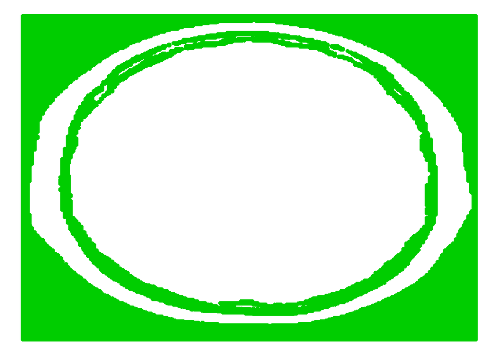

```r
BK <- ggplot(data = RMI_Kmeans_segmented, aes(x = y, y = -x)) +
  geom_point(colour = factor(RMI_Kmeans_segmented$clus1))+
      theme_void() + theme(legend.position="none")

BK
```

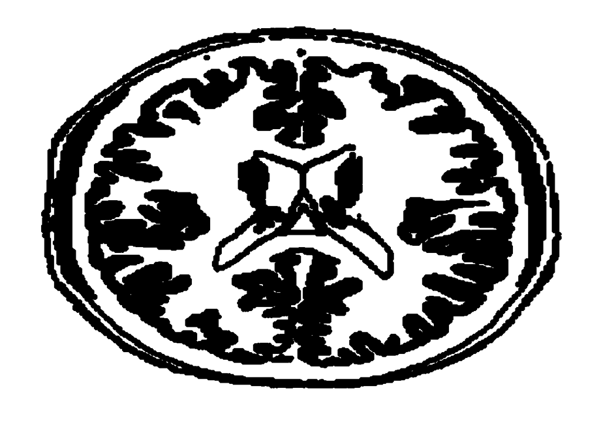

```r
GM <- ggplot(data = RMI_Kmeans_segmented, aes(x = y, y = -x)) +
  geom_point(colour = factor(RMI_Kmeans_segmented$clus2)) +
      theme_void() + theme(legend.position="none")
GM
```

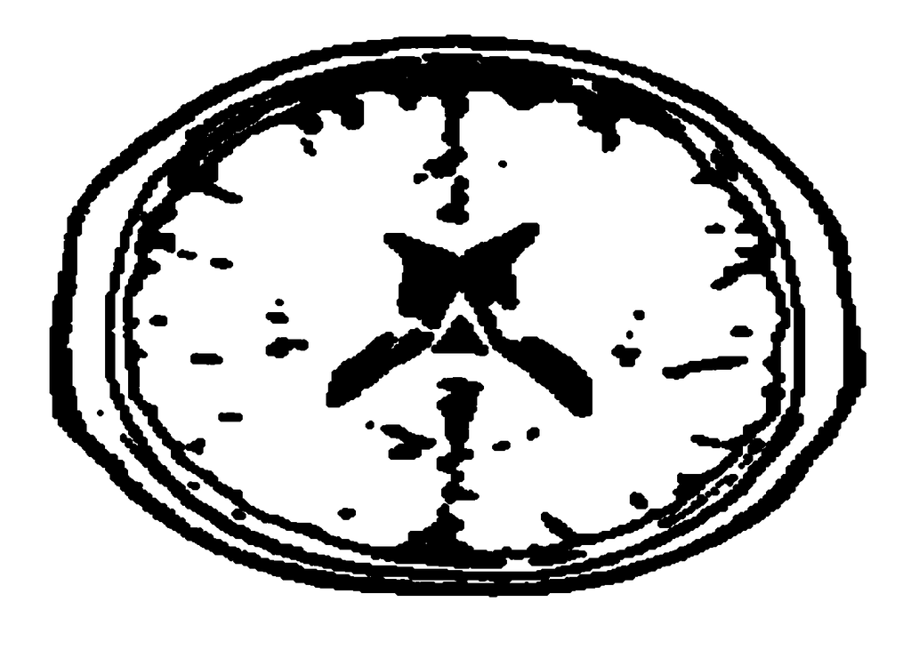

```r
CSF <- ggplot(data = RMI_Kmeans_segmented, aes(x = y, y = -x)) +
  geom_point(colour = factor(RMI_Kmeans_segmented$clus3)) +
      theme_void() + theme(legend.position="none")
CSF
```

[figure not shown]

```r
WM <- ggplot(data = RMI_Kmeans_segmented, aes(x = y, y = -x)) +
  geom_point(colour = factor(RMI_Kmeans_segmented$clus4)) +
      theme_void() + theme(legend.position="none")

WM
```

2) A partir de l’image d’étiquettes que vous avez précédemment crée, générez quatre images de masques contenant les masques de chaque région et sauvegardez les sous le nom « csf_methode.jpg », « gm_methode.jpg », « wm_methode.jpg » et “background.jpg”.

3. Affichez dans une même fenêtre les masques obtenus avec votre méthode de classification ainsi que les masques représentant la vérité terrain : « csf_mask.jpg », « wm_mask.jpg » et « gm_mask.jpg » calculés à la section III)

```python
wm_mask      = cv2.imread('data/wm_mask.jpg')
WhiteMatter  = cv2.imread('data/WhiteMatter.jpg')
WhiteMatter  = cv2.resize(WhiteMatter, (wm_mask.shape[1],wm_mask.shape[0]))
plt.subplot(1, 2, 1)
plt.imshow(wm_mask),plt.title('wm_mask')
```

```
## (<matplotlib.image.AxesImage object at 0x00000000060CE208>, Text(0.5,1,'wm_mask'))
```

```python
plt.subplot(1, 2, 2)
plt.imshow(WhiteMatter),plt.title('wm_mask_kmeans')
```

```
## (<matplotlib.image.AxesImage object at 0x00000000060F8B00>, Text(0.5,1,'wm_mask_kmeans'))
```

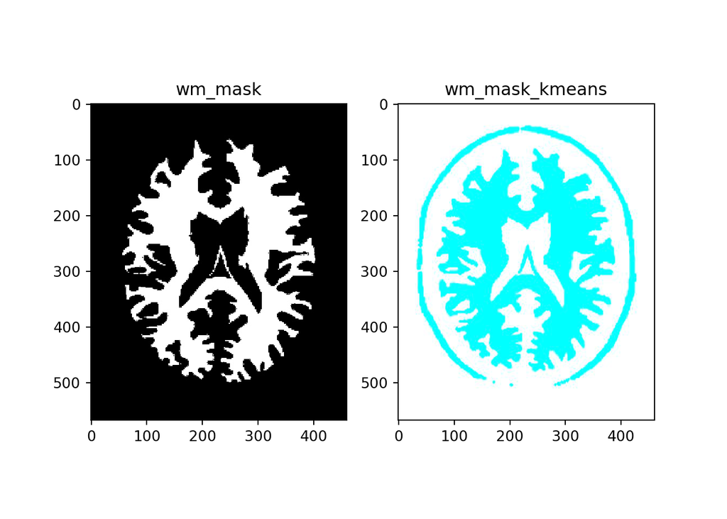

```python
plt.show()
```

```python
gm_mask    = cv2.imread('data/gm_mask.jpg')
GrayMatter = cv2.imread('data/GrayMatter.jpg')
GrayMatter  = cv2.resize(GrayMatter, (gm_mask.shape[1],gm_mask.shape[0]))
plt.subplot(1, 2, 1)
plt.imshow(gm_mask),plt.title('gm_mask')
```

```
## (<matplotlib.image.AxesImage object at 0x000000000666CFD0>, Text(0.5,1,'gm_mask'))
```

```python
plt.subplot(1, 2, 2)
plt.imshow(GrayMatter),plt.title('gm_mask_kmeans')
```

```
## (<matplotlib.image.AxesImage object at 0x00000000066ED6A0>, Text(0.5,1,'gm_mask_kmeans'))
```

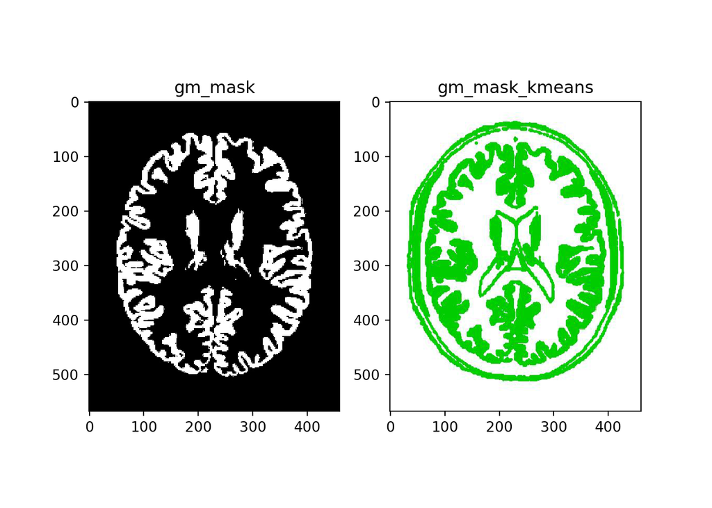

```python
plt.show()
```

```python
csf_mask      = cv2.imread('data/csf_mask.jpg')
CSFMask       = cv2.imread('data/CSF.jpg')
CSFMask       = cv2.resize(CSFMask, (csf_mask.shape[1], csf_mask.shape[0]))
plt.subplot(1, 2, 1)
plt.imshow(csf_mask),plt.title('csf_mask')
```

```
## (<matplotlib.image.AxesImage object at 0x00000000069C4C88>, Text(0.5,1,'csf_mask'))
```

```python
plt.subplot(1, 2, 2)
plt.imshow(CSFMask),plt.title('CSFMask_kmeans')
```

```
## (<matplotlib.image.AxesImage object at 0x0000000007BF2358>, Text(0.5,1,'CSFMask_kmeans'))
```

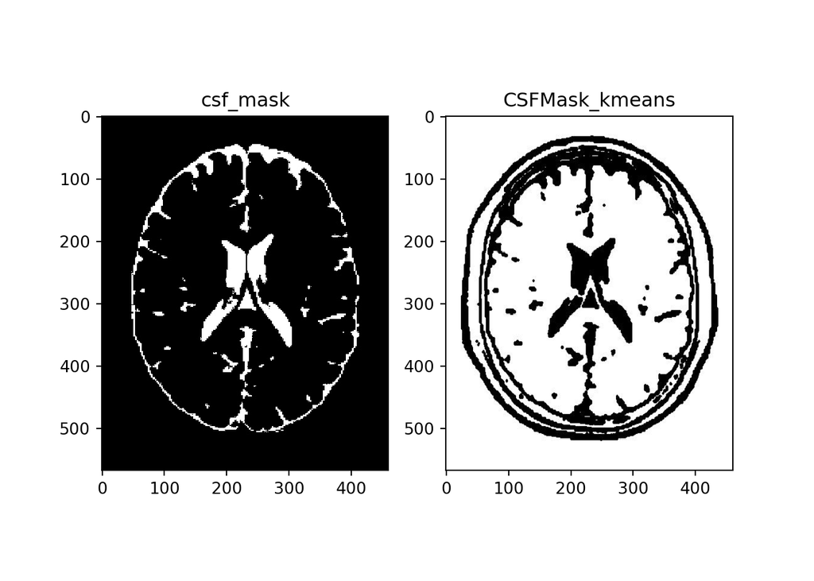

```python
plt.show()
```